# Compare H3K27ac with gene expression (RNAseq)

last changed: 2023-08-01

# Correlation of most differentially expressed genes with H3K27ac

## Calculate log2 fold change of gene expression

To find the most differentially expressed genes the significant LRT results were loaded and the actual counts were extracted. These were then used to calculate the log2 fold-change between the time points 0/0.5 hpi and 4 hpi. To get a more robust value for sorting the log2 fold-change was multiplied with -log10(adj.p) and the resulting value was then used to order the genes in decreasing order starting with the most differential expressed genes.

```r
> LRT.RNAseq <- readRDS(file = "./../Significance_testing/Data/LRT_RNAseq_sig.rds")
> info.RNAseq <- colData(LRT.RNAseq)
>
> # filter RNAseq for significant results:
> res.LRT <- results(LRT.RNAseq)
> res.LRT.sig <- res.LRT[which(res.LRT$padj <= 0.05), ]
> res.LRT.sig <- res.LRT.sig[order(res.LRT.sig$padj) ,]
>
> # calculate log2-fold. changes
> counts.RNAseq <- DESeq2::counts(LRT.RNAseq, normalize = T)
> counts.RNAseq.sig <- counts.RNAseq[rownames(res.LRT.sig) ,]
>
> # calculate log2 fold change for significant genes:
> log2.change <- apply(counts.RNAseq.sig, 1, function(row){
+   log2(mean(row[which(info.RNAseq$Time == 4)]) /
+          mean(row[which(info.RNAseq$Time == 0 | info.RNAseq$Time == 0.5)])
+       )
+ })
>
> LRT.sig <- mutate(res.LRT.sig %>% as.data.frame(), log2_fold_change = log2.change)
>
> # calculate adjusted log2-fold-change:
> LRT.sig <- mutate(LRT.sig, adj_log2fc = abs(LRT.sig$log2_fold_change * (-log10(LRT.sig$padj))))
>
> # sort by adj_log2fc:
> LRT.sig.adj <- LRT.sig[order(LRT.sig$adj_log2fc, decreasing = T) ,]
```

## Annotate genes to H3K27ac peaks

Next, the H3K27ac peaks were annotated to the corresponding genes. Thus, a GRanges object was constructed and this was then used to annotate the peaks.

```r
> dds.H3ac <- readRDS("./Data/rlog_H3K27ac.rds")
>
> rlog.H3ac <- assay(dds.H3ac)
> info.H3ac <- colData(dds.H3ac) %>% as.data.frame()
>
> # construct GRanges object:
> chr <- str_split_i(rownames(rlog.H3ac), ":", 1)
> pos <- str_split_i(rownames(rlog.H3ac), ":", 2)
> start <- as.integer(str_split_i(pos, "-", 1))
> end <- as.integer(str_split_i(rownames(rlog.H3ac), "-", 2))
>
> peaks.H3ac <- GRanges(seqnames = chr,
+                       ranges =IRanges(start = start, end = end))
>
> # get list of protein-coding genes:
> TxDb.protein.coding <- loadDb(file = "./Data/TxDb.protein.coding.sqlite")
> seqlevelsStyle(TxDb.protein.coding) <- "UCSC"
>
> # peak annotation:
> peaks.cod <- annotatePeak(peaks.H3ac,
+                          TxDb = TxDb.protein.coding,
+                          tssRegion = c(-3000, 3000),
+                          verbose = FALSE)
```

Since the output contains the wrong annotation IDs these need to be changed into ENTREZ IDs. This was accomplished with the following function:

```r
> conv2table<-function(x){
+   eg = bitr(x@anno$geneId, fromType="ENSEMBL", toType="SYMBOL", OrgDb="org.Hs.eg.db")
+   ez = bitr(x@anno$geneId, fromType="ENSEMBL", toType="ENTREZID", OrgDb="org.Hs.eg.db")
+   anno.table<-x@anno
+   #add gene symbols
+   mx<-match(anno.table$geneId, eg$ENSEMBL)
+   anno.table$gene_symbol<-eg[mx,"SYMBOL"]
+   #add gene entrezID
+   mx<-match(anno.table$geneId, ez$ENSEMBL)
+   anno.table$gene_entrez<-ez[mx,"ENTREZID"]
+
+   res.table<-cbind(
+     chr=as.vector(seqnames(anno.table)),
+     start=start(anno.table),
+     end=end(anno.table),
+     name=anno.table$name,
+     peak.p_adj=anno.table$qValue,
+     strand=rep(".", length(anno.table)),
+     genome_anno=anno.table$annotation,
+     gene_symbol=anno.table$gene_symbol,
+     gene_entrez=anno.table$gene_entrez,
+     distanceToTSS=anno.table$distanceToTSS,
+     transcriptId=anno.table$transcriptId,
+     geneId_ensembl=anno.table$geneId)
+ }
>
> # add entrez IDs:
> peaks.cod.2 <- conv2table(peaks.cod) %>% as.data.frame()
>
> # filter peaks for 1kb to TSS:
> peaks.cod.1kb <- peaks.cod.2[which(abs(peaks.cod.2$distanceToTSS %>% as.integer()) <= 1000), ]
>
> peaks.cod.1kb <- mutate(peaks.cod.1kb, peak_pos = paste0(peaks.cod.1kb$chr, ":", peaks.cod.1kb$start, "-", peaks.cod.1kb$end))
```

## Correlation between most differentially expreessed genes (RNAseq) and H3K27ac

Since the two experiments have different time points, the matrices need to be filtered for the required time points. Then, the median over the replicates can be calculated. For the H3K27ac the matrix was additionally separated by construct. Furthermore, the data was centered around 0 by subtracting the row mean from every value for each of the experiments.

```r
> times <- c(0, 1, 2, 4)
>
> # H3K27ac:
> ind.H3.1 <- which(info.H3ac$construct == "U2OS31")
> ind.H3.3 <- which(info.H3ac$construct == "U2OS33")
>
> m.H3.1ac <- rlog.H3ac[ ,ind.H3.1]
> m.H3.3ac <- rlog.H3ac[ ,ind.H3.3]
>
> m.H3.1ac.median <- matrix(data = NA, ncol = 4, nrow = nrow(m.H3.1ac))
> rownames(m.H3.1ac.median) <- rownames(m.H3.1ac)
> colnames(m.H3.1ac.median) <- c("T0h", "T1h", "T2h", "T4h")
>
> m.H3.3ac.median <- m.H3.1ac.median
>
> for (t in 1:4) {
+   t.0.H3.1 <- which(info.H3ac[ind.H3.1, "time"] == times[t])
+   medians <- apply(m.H3.1ac[,  t.0.H3.1], 1, median)
+   m.H3.1ac.median[, t] <- medians
+ }
>
> for (t in 1:4) {
+   t.0.H3.3 <- which(info.H3ac[ind.H3.3, "time"] == times[t])
+   medians <- apply(m.H3.3ac[,  t.0.H3.3], 1, median)
+   m.H3.3ac.median[, t] <- medians
+ }
>
> m.H3.1ac.norm <- apply(m.H3.1ac.median, 1, function(row) row - mean(row)) %>% t()
> m.H3.3ac.norm <- apply(m.H3.3ac.median, 1, function(row) row - mean(row)) %>% t()
>
> # RNAseq:
> dds.RNAseq <- readRDS(file = "./../Significance_testing/Data/rlog_RNAseq_sig.rds")
>
> rlog.RNAseq <- assay(dds.RNAseq)
> info.RNAseq2 <- colData(dds.RNAseq) %>% as.data.frame()
>
> m.RNAseq.median <- matrix(data = NA, ncol = 4, nrow = nrow(rlog.RNAseq))
> rownames(m.RNAseq.median) <- rownames(rlog.RNAseq)
> colnames(m.RNAseq.median) <- c("T0h", "T1h", "T2h", "T4h")
>
> for (t in 1:4) {
+   ind <- which(info.RNAseq2[, "Time"] == times[t])
+   if (t == 1)
+     medians <- rlog.RNAseq[, ind]
+   else
+     medians <- apply(rlog.RNAseq[, ind], 1, median)
+   m.RNAseq.median[, t] <- medians
+ }
>
> m.RNAseq.norm <- apply(m.RNAseq.median, 1, function(row) row - mean(row)) %>% t()
```

Some of the peaks can be annotated to the same gene, thus these duplicates need to be filtered out. Subsequently, the corresponding peak - gene pairs are added to the results from the RNAseq.

```r
> peaks.cod.1kb.ndub <- peaks.cod.1kb[order(peaks.cod.1kb$distanceToTSS %>% as.integer() %>% abs()), ]
> peaks.cod.1kb.ndub  <- peaks.cod.1kb.ndub[!duplicated(peaks.cod.1kb.ndub$geneId_ensembl), ]
>
> corr.peaks <- ifelse(rownames(LRT.sig.adj) %in% peaks.cod.1kb$geneId_ensembl,
+                peaks.cod.1kb.ndub$peak_pos,
+                "none")
>
> LRT.RNAseq.peaks <- mutate(LRT.sig.adj, corr_peak = corr.peaks)
>
> # add gene IDs to data frame:
> gene.ID <- biomaRt::select(org.Hs.eg.db, keys = rownames(LRT.RNAseq.peaks),
+                  columns = "SYMBOL", keytype = "ENSEMBL")
> gene.ID <- gene.ID[!duplicated(gene.ID$ENSEMBL), ]
> rownames(gene.ID) <- gene.ID$ENSEMBL
>
> LRT.RNAseq.genes <- mutate(LRT.RNAseq.peaks, gene = gene.ID[rownames(LRT.RNAseq.peaks), "SYMBOL"])
```

This data frame was then used to sort both matrices. For the H3K27ac it was additionally required to check if a corresponding peak exists. If there was no corresponding peak for the respective gene, the values were set to 0.

```r
> # RNAseq:
> m.RNAseq.sort <- m.RNAseq.norm[rownames(LRT.RNAseq.genes),]
>
> # H3K27ac:
> m.H3.1ac.sort <- matrix(NA,
+                         LRT.RNAseq.genes %>% nrow(),
+                         4,
+                         dimnames = list(rownames(m.RNAseq.sort), c("T0h", "T1h", "T2h", "T4h")))
>
> for (x in 1:nrow(LRT.RNAseq.genes)) {
+   if (LRT.RNAseq.genes[x, "corr_peak"] == "none")
+    m.H3.1ac.sort[x, ] <- 0
+   else
+    m.H3.1ac.sort[x, ] <- m.H3.1ac.norm[LRT.RNAseq.genes[x, "corr_peak"], ]
+ }
>
> m.H3.3ac.sort <- matrix(NA,
+                         LRT.RNAseq.genes %>% nrow(),
+                         4,
+                         dimnames = list(rownames(m.RNAseq.sort), c("T0h", "T1h", "T2h", "T4h")))
>
> for (x in 1:nrow(LRT.RNAseq.genes)) {
+   if (LRT.RNAseq.genes[x, "corr_peak"] == "none")
+     m.H3.3ac.sort[x, ] <- 0
+   else
+     m.H3.3ac.sort[x, ] <- m.H3.3ac.norm[LRT.RNAseq.genes[x, "corr_peak"], ]
+ }
```

Next, the correlation was calculated for H3.1/H3.3 K27ac and RNAseq, as follows:

```r
> # correlation for H3.1K27ac and RNAseq
> cor.H3.1ac.RNAseq <- c()
>
> for (i in 1:nrow(m.H3.1ac.sort)) {
+   curr.corr <- cor(m.H3.1ac.sort[i, ], m.RNAseq.sort[i, ], method = "pearson")
+   cor.H3.1ac.RNAseq <- c(cor.H3.1ac.RNAseq, curr.corr)
+ }
> names(cor.H3.1ac.RNAseq) <- rownames(m.H3.1ac.sort)
>
> # correlation for H3.3K27ac and RNAseq
> cor.H3.3ac.RNAseq <- c()
>
> for (i in 1:nrow(m.H3.3ac.sort)) {
+   curr.corr <- cor(m.H3.3ac.sort[i, ], m.RNAseq.sort[i, ], method = "pearson")
+   cor.H3.3ac.RNAseq <- c(cor.H3.3ac.RNAseq, curr.corr)
+ }
> names(cor.H3.3ac.RNAseq) <- rownames(m.H3.3ac.sort)
```

For plotting a data frame with information about the experiment, genes, times, and correlation values were required.

```r
> cor.H3.1ac.rnd <- round(cor.H3.1ac.RNAseq, 3)
> cor.H3.1ac.rnd[is.na(cor.H3.1ac.rnd)] <-"NA"
> cor.H3.3ac.rnd <- round(cor.H3.3ac.RNAseq, 3)
> cor.H3.3ac.rnd[is.na(cor.H3.3ac.rnd)] <-"NA"
>
> corr.H3.1 <- data.frame(experiment = rep("H3.1K27ac", each = length(cor.H3.1ac.rnd)) %>% as.factor(),
+                    R = stri_pad_both(cor.H3.1ac.rnd, width = 7),
+                    genes = LRT.RNAseq.genes$gene %>% as.factor)
>
> corr.H3.3 <- data.frame(experiment = rep("H3.3K27ac", each = length(cor.H3.3ac.rnd)) %>% as.factor(),
+                    R = stri_pad_both(cor.H3.3ac.rnd, width = 7),
+                    genes = LRT.RNAseq.genes$gene %>% as.factor)
>
> df.cor <- cbind.data.frame(m.H3.1ac.sort, m.H3.3ac.sort, m.RNAseq.sort)
>
> genes <- rep(LRT.RNAseq.genes$gene, each = 12) %>% as.factor
> time <- rep(c(0,1,2,4), length(genes)/4)
> experiment <- rep(
+   rep(c("H3.1K27ac", "H3.3K27ac", "expression"),
+       each = 4),
+   length(genes)/12) %>% as.factor
> values <- Reduce(df.cor %>% t(), f = c)
>
> data.cor <- data.frame(genes = genes,
+                         time = time,
+                         experiment = experiment,
+                         values = values)
```

The correlation between the top 12 most differentially expressed genes and the H3K27ac was plotted as follows:

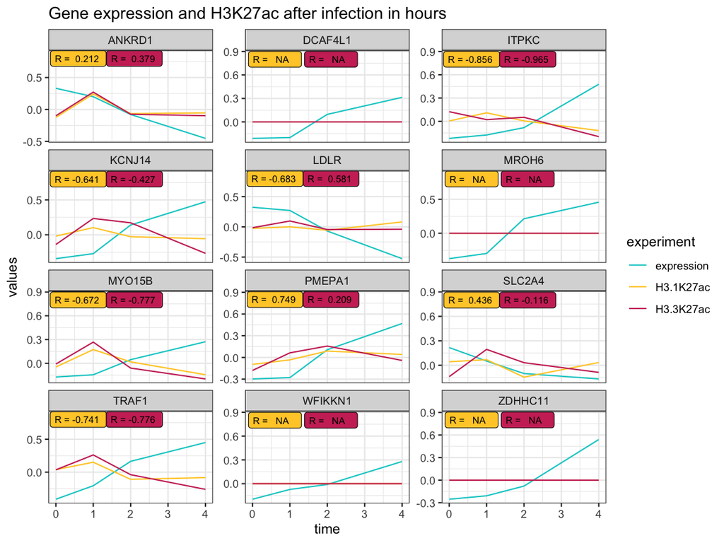

```r
> n.genes <- 12
>
> ggplot(data.cor[1:(12*n.genes), ], aes(x = time, y = values, color = experiment)) +
+   geom_line() +
+   facet_wrap(~ genes, ncol = 3, scales = "free_y") +
+   theme_bw() +
+   scale_color_manual(values = c("cyan3", "#FFCC33", "#CC3366")) +
+   labs(title = "Gene expression and H3K27ac after infection in hours") +
+   geom_label(data = corr.H3.1[1:n.genes, ],
+             aes(x = 0.6, y = 0.8,
+                 label = paste("R =", R)),
+             show.legend = F,
+             color = "black",
+             fill = "#FFCC33",
+             size = 2.65) +
+   geom_label(data = corr.H3.3[1:n.genes, ],
+             aes(x = 2.1, y = 0.8,
+                 label = paste("R =", R)),
+             show.legend = F,
+             color = "black",
+             fill = "#CC3366",
+             size = 2.65) +
+   aes(ymax = 0.86)
```

# Correlation between all significantly changed genes and H3K27ac by cluster

At first the genes/peaks need to be annotated to the clustering for the RNAseq experiment (differentially expressed genes). For this the peak annotation (`peaks.cod.1kb`) and clustering are required. Then this data frame can be used to filter the matrices generated above for suitable gene - peak pairs.

```r
> # load clustering
> kmeans.k4 <- readRDS("./../Clustering/Data/kmeans.rds")
>
> clus.kmeans <- melt(kmeans.k4$cluster)
> clus.kmeans <- cbind(clus.kmeans, 1:nrow(clus.kmeans))
> colnames(clus.kmeans) <- c("cluster", "ind")
> clus.kmeans <- clus.kmeans[order(clus.kmeans[, "cluster"]), ]
>
> # annotate genes to cluster as a list:
> ind.cluster1 <- clus.kmeans[which(clus.kmeans[, "cluster"] == 1), "ind"]
> ind.cluster2 <- clus.kmeans[which(clus.kmeans[, "cluster"] == 2), "ind"]
> ind.cluster3 <- clus.kmeans[which(clus.kmeans[, "cluster"] == 3), "ind"]
> ind.cluster4 <- clus.kmeans[which(clus.kmeans[, "cluster"] == 4), "ind"]
>
> genes.k1 <- rlog.RNAseq[ind.cluster1, ] %>% rownames()
> genes.k2 <- rlog.RNAseq[ind.cluster2, ] %>% rownames()
> genes.k3 <- rlog.RNAseq[ind.cluster3, ] %>% rownames()
> genes.k4 <- rlog.RNAseq[ind.cluster4, ] %>% rownames()
>
> clus.genes <- list("1" = genes.k1, "2" = genes.k2, "3" = genes.k3, "4" = genes.k4)
>
> genes <- rownames(rlog.RNAseq)
>
> # find intersecting peak - gene pairs and filter matrices:
> genes.both <- intersect(genes, peaks.cod.1kb$geneId_ensembl)
> peaks.both <- peaks.cod.1kb[which(peaks.cod.1kb$geneId_ensembl %in% genes.both), ]
>
> m.H3.1ac.both <- m.H3.1ac.median[peaks.both$peak_pos, ]
> m.H3.3ac.both <- m.H3.3ac.median[peaks.both$peak_pos, ]
> m.RNAseq.both <- m.RNAseq.median[peaks.both$geneId_ensembl, ]
```

Next, the correlation was calculated for H3.1/H3.3 K27ac and RNAseq, as follows:

```r
> cor.H3.1ac <- c()
>
> for (i in 1:nrow(m.RNAseq.both)) {
+   curr.corr <- cor(m.H3.1ac.both[i, ], m.RNAseq.both[i, ], method = "pearson")
+   cor.H3.1ac <- c(cor.H3.1ac, curr.corr)
+ }
>
> # H3.3ac vs RNA seq:
> cor.H3.3ac <- c()
>
> for (i in 1:nrow(m.RNAseq.both)) {
+   curr.corr <- cor(m.H3.3ac.both[i, ], m.RNAseq.both[i, ], method = "pearson")
+   cor.H3.3ac <- c(cor.H3.3ac, curr.corr)
+ }
>
> cor.H3ac.RNAseq <- data.frame(U2OS31 = cor.H3.1ac,
+                                   U2OS33 = cor.H3.3ac,
+                                   gene = rownames(m.RNAseq.both),
+                                   peak = rownames(m.H3.1ac.both))
```

```r
> # add cluster annotations to correlation matrix:
> peak.pos.clus <- lapply(clus.genes, function(l)
+   peaks.cod.1kb[which(peaks.cod.1kb[, "geneId_ensembl"] %in% l), ]
+   )
>
> cor.cluster <- mutate(cor.H3ac.RNAseq, cluster = NA)
>
> for (step in 1:4) {
+   ind <- peak.pos.clus[[step]]$peak_pos
+   cor.cluster[which(cor.cluster$peak %in% ind), "cluster"] <- step
+ }
```

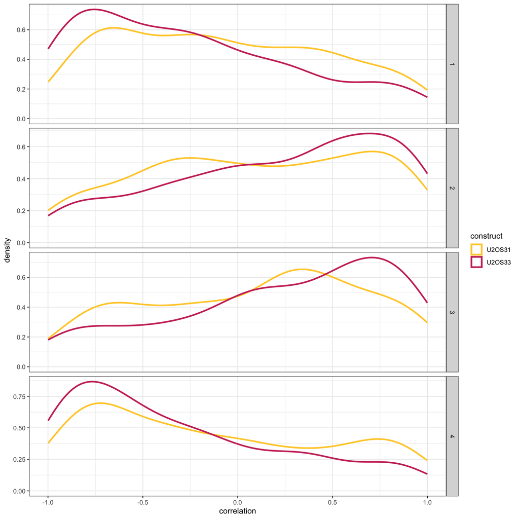

```r
> ggplot(cor.cluster) +
+   geom_density(aes(x = U2OS31, color = "U2OS31"), linewidth = 1.05) +
+   geom_density(aes(x = U2OS33, color = "U2OS33"), linewidth = 1.05) +
+   scale_color_manual(name = "construct",
+                      breaks = c("U2OS31", "U2OS33"),
+                      values = c("U2OS31" = "#FFCC33", "U2OS33" = "#CC3366")) +
+   labs(x = "correlation") +
+   theme_bw() +
+   facet_grid(rows = cor.cluster$cluster, scales = "free_y")
```